# Schraven662064142

Problem 1

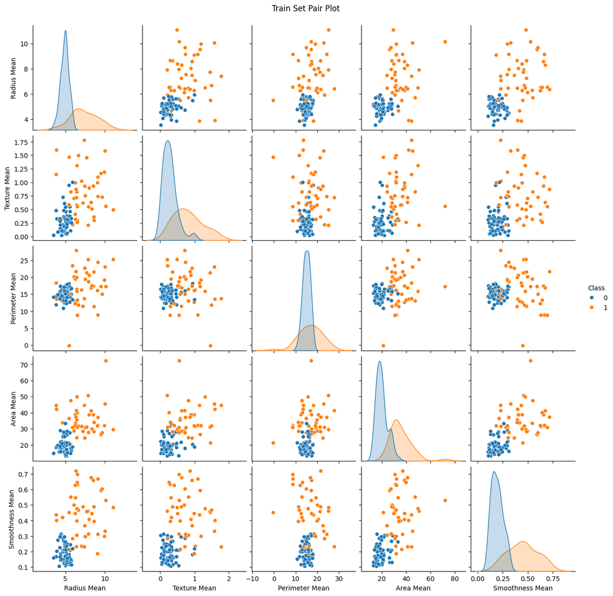

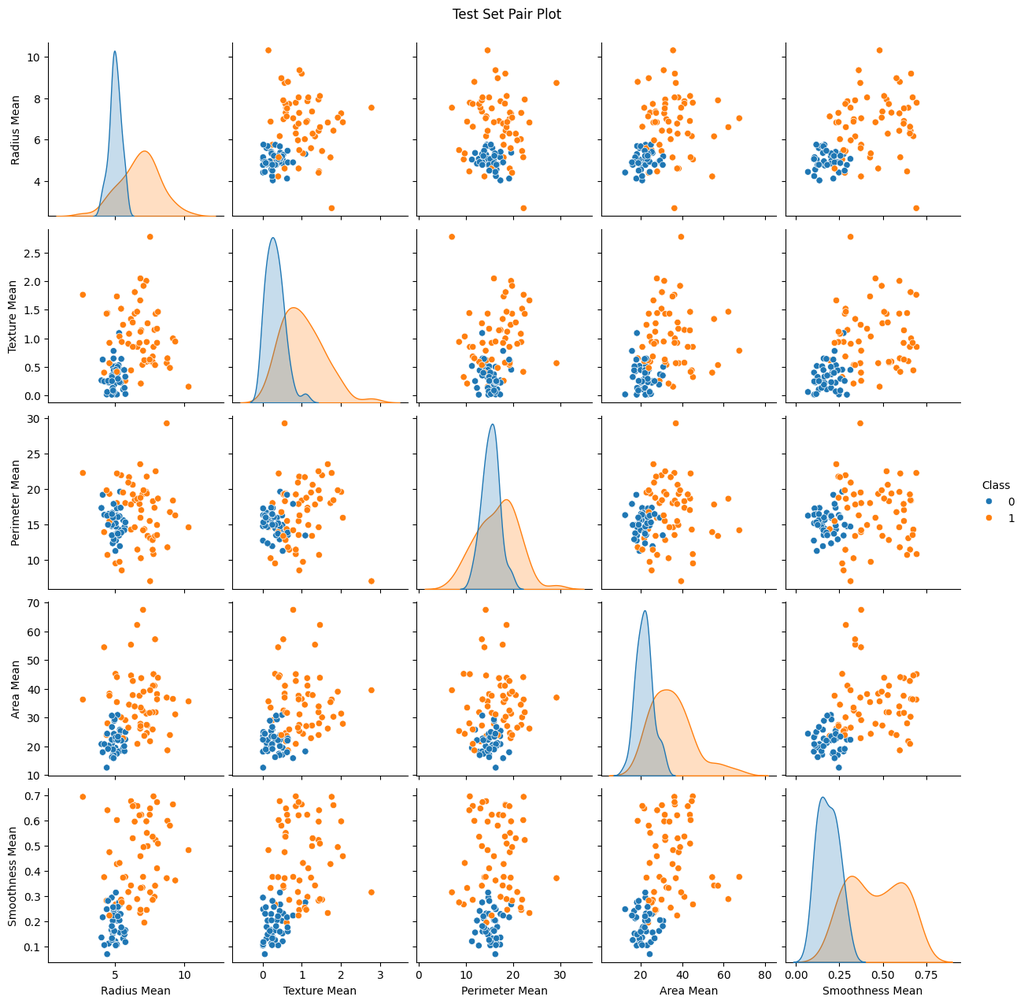

```python
import pandas as pd
import seaborn as sns
import matplotlib.pyplot as plt

# Load datasets
train_df = pd.read_csv('semiconductor_train_set.csv')
test_df = pd.read_csv('semiconductor_test_set.csv')

# Plot train set
sns.pairplot(train_df, hue='Class')
plt.suptitle('Train Set Pair Plot', y=1.02)
plt.show()

# Plot test set
sns.pairplot(test_df, hue='Class')
plt.suptitle('Test Set Pair Plot', y=1.02)
plt.show()
```

Problem 2

```python
from sklearn.neighbors import KNeighborsClassifier

# Separate features and target; from class 0 and 1 simultaneously
X_train = train_df.drop('Class', axis=1)
y_train = train_df['Class']
X_test = test_df.drop('Class', axis=1)
y_test = test_df['Class']

# Initialize and train the k-NN model
knn = KNeighborsClassifier(n_neighbors=3, metric='euclidean')
knn.fit(X_train, y_train)
```

```
KNeighborsClassifier(metric='euclidean', n_neighbors=3)
```

2. Test set numerical output (predictions): [0 1 1 1 0 1 1 0 1 0 0 1 0 1 0 1 1 0 0 1 0 0 0 1 0 1 1 0 1 0 1 1 0 0 1 0 0 1 0 0 0 0 0 1 0 0 0 1 1 0 0 0 0 1 0 0 0 0 1 1 0 0 0 1 1 1 0 1 1 0 0 0 0 0 0 0 1 1 0 0 1 1 1 1 1 1 0 1 0 1 0 1 1 1 0 1 1 1 1 1]

Problem 3

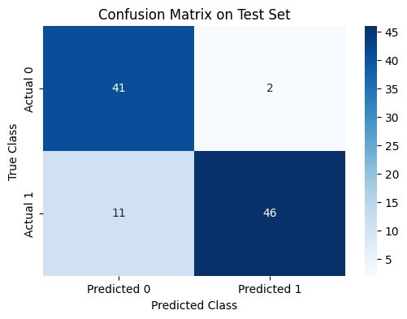

```python
from sklearn.metrics import confusion_matrix

# Predict
y_pred = knn.predict(X_test)

cm = confusion_matrix(y_test, y_pred)

# Plot
plt.figure(figsize=(6,4))
sns.heatmap(cm, annot=True, fmt='d', cmap='Blues',
            xticklabels=['Predicted 0', 'Predicted 1'],
            yticklabels=['Actual 0', 'Actual 1'])
plt.title('Confusion Matrix on Test Set')
plt.ylabel('True Class')
plt.xlabel('Predicted Class')
plt.show()
```

Problem 4

```python
# Misclassified = predicted as Class 0 (False Negative).
misclassified_defective = cm[1, 0]
print(f"Misclassified defective samples: {misclassified_defective}")
```

```
Misclassified defective samples: 11
```

Problem 5

```python
from sklearn.metrics import precision_score, recall_score, f1_score, accuracy_score

# Calculating macro-average metrics
avg_precision = precision_score(y_test, y_pred, average='macro')
avg_recall = recall_score(y_test, y_pred, average='macro')
avg_f1 = f1_score(y_test, y_pred, average='macro')
accuracy = accuracy_score(y_test, y_pred)

print(f"Average Precision: {avg_precision:.4f}")
print(f"Average Recall: {avg_recall:.4f}")
print(f"Average F1 Score: {avg_f1:.4f}")
print(f"Accuracy: {accuracy:.4f}")
```

```
Average Precision: 0.8734
Average Recall: 0.8803
Average F1 Score: 0.8697
Accuracy: 0.8700
```

Problem 6

```python
from sklearn.cluster import KMeans
from sklearn.metrics import silhouette_score

# (assuming 2 clusters for 2 classes) train k-means
kmeans = KMeans(n_clusters=2, random_state=42, n_init=10)
kmeans.fit(X_train)

# Predict clusters
test_cluster_labels = kmeans.predict(X_test)

# Calculate silhouette score
sil_score = silhouette_score(X_test, test_cluster_labels)
print(f"Silhouette Score on Test Data: {sil_score:.4f}")
```

```
Silhouette Score on Test Data: 0.4902
```